# Problema 4 - Checkpoint 3

Diogo Florêncio

# Os dados

Os dados compõe uma amostra de dados da atividade global do github, neles contém a contagem de quantas pessoas editaram arquivos para cada extensão de arquivo no período de 2016 à 2017. Estes dados estão disponíveis [aqui](https://raw.githubusercontent.com/nazareno/fpcc2/master/datasets/github-users-committing-filetypes.csv). Para essa análise as extensões consideradas foram `.java` e `.py`. Objetivo dessa análise é estudar a `popularidade` dessas extensões durante a semana e aos finais de semana.

```r
amostra <- read.csv("../dados/github-users-committing-filetypes.csv")
#formatando data
amostra = amostra %>%
        mutate(date = as.Date(paste(month_day,the_month,the_year),format = "%d %m %Y")) %>%
        mutate(week_day = (weekdays(as.Date(date))))%>%
        select(file_extension, week_day, date, users)
```

# Como se comporta a popularidade de java e python no periodo de 2016 à 2017?

Para responder essa pergunta vamos estimar a popularidade das linguagens para cada ano e depois comparar suas proporções individualmente. O parâmetro utilizado para mensurar a popularidade de cada linguagem foi a quantidade mediana de edições. A amostra descreve edições em arquivos até maio de 2017, a fim equiparar a análise considerei apenas o periodo de janeiro à abril de cada ano.

```r
#filtrando dados de interesse
java_2016 = filter(amostra, file_extension == "java",
                          month(date) %in% c("1","2","3","4"),
                          year(date) == "2016")
java_2017 = filter(amostra, file_extension == "java",
                          month(date) %in% c("1","2","3","4"),
                          year(date) == "2017")
py_2016 = filter(amostra, file_extension == "py",
                          month(date) %in% c("1","2","3","4"),
                          year(date) == "2016")
py_2017 = filter(amostra, file_extension == "py",
                          month(date) %in% c("1","2","3","4"),
                          year(date) == "2017")
```

### Popularidade de Java

Análisando a amostra por meio do método bootstrap estimei valores da popularidade de `java`, para cada ano. A análise foi realizada com confiança de 95%, o bootstrap gerou 10.000 reamostragens. Os resultados foram bem expressivos, a mediana de edições foi estimada em [3845 ; 4010] para 2016 e [3135 ; 3444] para 2017.

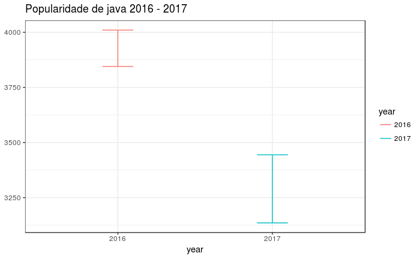

```r
#gerando a estimativa por meio de bootstrap
estimativa_java_2016 =  bootstrap(java_2016, median(users)) %>%
                    CI.percentile(probs = c(.025, .975)) %>%
                    as.data.frame() %>%
                    mutate(year = "2016")

#gerando a estimativa por meio de bootstrap
estimativa_java_2017 =  bootstrap(java_2017, median(users)) %>%
                    CI.percentile(probs = c(.025, .975)) %>%
                    as.data.frame() %>%
                    mutate(year = "2017")
#plotando estimativa de popularidade por ano
data.frame(rbind(estimativa_java_2016, estimativa_java_2017)) %>%
  ggplot(aes(x = year, ymin = X2.5., ymax = X97.5., color = year)) +
  geom_errorbar(width = .2)+
  ggtitle("Popularidade de java 2016 - 2017")
```

A diferença de popularidade no periodo de interesse é sigficativa, a estimativa aponta uma queda na popularidade de `java`. Este resultado é relavante pois sugere que os desenvolvedores, por algum motivo, estejam trocando `java` por outras tecnologias.

### Popularidade de Python

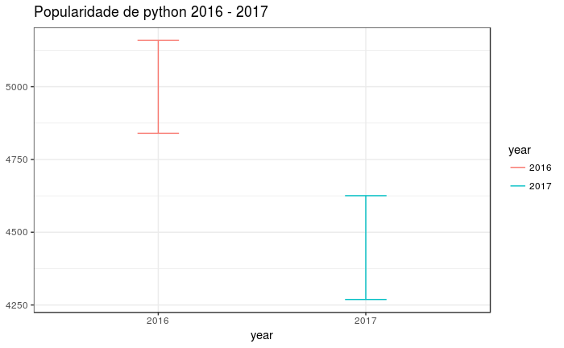

```r
#gerando a estimativa por meio de bootstrap
estimativa_py_2016 =  bootstrap(py_2016, median(users)) %>%
                    CI.percentile(probs = c(.025, .975)) %>%
                    as.data.frame() %>%
                    mutate(year = "2016")
#gerando a estimativa por meio de bootstrap
estimativa_py_2017 =  bootstrap(py_2017, median(users)) %>%
                    CI.percentile(probs = c(.025, .975)) %>%
                    as.data.frame() %>%
                    mutate(year = "2017")
#plotando estimativa de popularidade por ano
data.frame(rbind(estimativa_py_2016, estimativa_py_2017)) %>%
  ggplot(aes(x = year, ymin = X2.5., ymax = X97.5., color = year)) +
  geom_errorbar(width = .2)+
  ggtitle("Popularidade de python 2016 - 2017")
```

# Qual linguagem teve a maior queda de popularidade?

Para responder essa pergunta estimei a estatística *p^ = media[mediana(2016)/mediana(2017)]*, que seria a razão entre os intervalos estimados para popularidade de cada linguagem para 2016 e 2017.

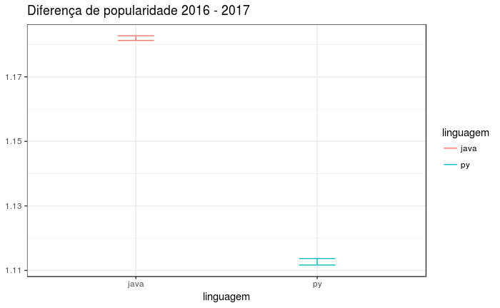

```r
# distribuição amostral da popularidade de java com 1000 elementos
dist_popularidade_java = data.frame(dist_popularidade_java = 1:1000) %>%
            group_by(dist_popularidade_java) %>%
            do(data.frame(media_2016 = sample(java_2016$users, 100) %>% median(),
                          media_2017 = sample(java_2017$users, 100) %>% median()))
# distribuição amostral da popularidade de python com 1000 elementos
dist_popularidade_py = data.frame(dist_popularidade_py = 1:1000) %>%
            group_by(dist_popularidade_py) %>%
            do(data.frame(media_2016 = sample(py_2016$users, 100) %>% median(),
                          media_2017 = sample(py_2017$users, 100) %>% median()))
#gerando estimativa da diferença de popularidade por meio de bootstrap
dif_popularidade_java =  bootstrap(dist_popularidade_java, mean(media_2016/media_2017)) %>%
                        CI.percentile(probs = c(.025, .975)) %>%
                        as.data.frame() %>%
                        mutate(linguagem = "java")
dif_popularidade_py =  bootstrap(dist_popularidade_py, mean(media_2016/media_2017)) %>%
                        CI.percentile(probs = c(.025, .975)) %>%
                        as.data.frame() %>%
                        mutate(linguagem = "py")
#plotando queda de popularidade por linguagem
data.frame(rbind(dif_popularidade_java, dif_popularidade_py)) %>%
  ggplot(aes(x = linguagem, ymin = X2.5., ymax = X97.5., color = linguagem)) +
  geom_errorbar(width = .2)+
  ggtitle("Diferença de popularidade 2016 - 2017")
```

A análise também foi realizada com confiança de 95%, o bootstrap gerou 10.000 reamostragens. Os intervalos estimados para `p^` foram [1.181856 ; 1.183293] para `java` e [1.111376 ; 1.113257] para `phyton`. Ou seja, pode-se dizer que a popularidade de java caiu 1.18 vezes entre 2016 e 2017. No caso de python sua popularidade caiu em 1.1 vezes, entre os mesmos anos. Este resultado é relevante pois apresenta a proporção da queda de popularidade para as duas linguagens de interesse.

# Existe alguma correlação linear entre a popularidade das linguagens?

Respondendo essa pergunta, estimei a correlação linear da popularidade de `java` e `python` para os anos de interesse. Mais uma vez a estimativa foi realizada com 95% de confiança, o bootstrap gerou novamente o padrão de 10.000 reamostragens.

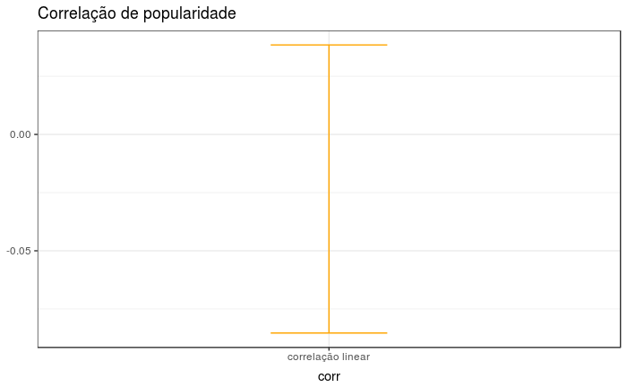

```r
java = filter(amostra, file_extension == "java")
py = filter(amostra, file_extension == "py")
popularidade_java_python = data.frame(popularidade_java_python = 1:1000) %>%
            group_by(popularidade_java_python) %>%
            do(data.frame(mediana_java = sample(java$users, 100) %>% median(),
                          mediana_py = sample(py$users, 100) %>% median()))
corr = bootstrap(popularidade_java_python, cor(mediana_java, mediana_py )) %>%
                        CI.percentile(probs = c(.025, .975)) %>%
                        as.data.frame() %>%
                        mutate(corr = "correlação linear")
#plotando correlação entre a popularidade de java e python
data.frame(corr) %>%
  ggplot(aes(x = corr, ymin = X2.5., ymax = X97.5.)) +
  geom_errorbar(width = .2, color= "orange") +
  ggtitle("Correlação de popularidade")
```